# PROBLEM STATEMENT•

```python
#Accuracy of training and testing data
print("Accuracy of the model on Training Data is - " ,lstm_model.evaluate(X_train,y_train_new)[1]*100 , "%")
print("Accuracy of the model on Testing Data is - " ,lstm_model.evaluate(X_test,y_test_new)[1]*100,"%")
```

```
Accuracy of the model on Training Data is -  36.826348304748535 %
Accuracy of the model on Testing Data is -  30.95238208770752 %
```

```python
# predicting the model on test data
#We cant directy use one hot encoded data hence following below steps
y_test_arg_l=np.argmax(Y_test,axis=1)
y_pred_test_l = np.argmax(lstm_model.predict(X_test),axis=1)
```

```python
#Accuracy of test data
acc_test_l=accuracy_score(y_test_arg_l, y_pred_test_l)
print('Accuracy of test data:',acc_test_l)
```

```
Accuracy of test data: 0.30952380952380953
```

```python
#Classification Report for test data
print(classification_report(y_test_arg_l, y_pred_test_l))
```

```
              precision    recall  f1-score   support

           0       0.00      0.00      0.00         9
           1       0.00      0.00      0.00        17
           2       0.00      0.00      0.00        27
           3       0.32      1.00      0.48        26
           4       0.00      0.00      0.00         5

    accuracy                           0.31        84
   macro avg       0.06      0.20      0.10        84
weighted avg       0.10      0.31      0.15        84
```

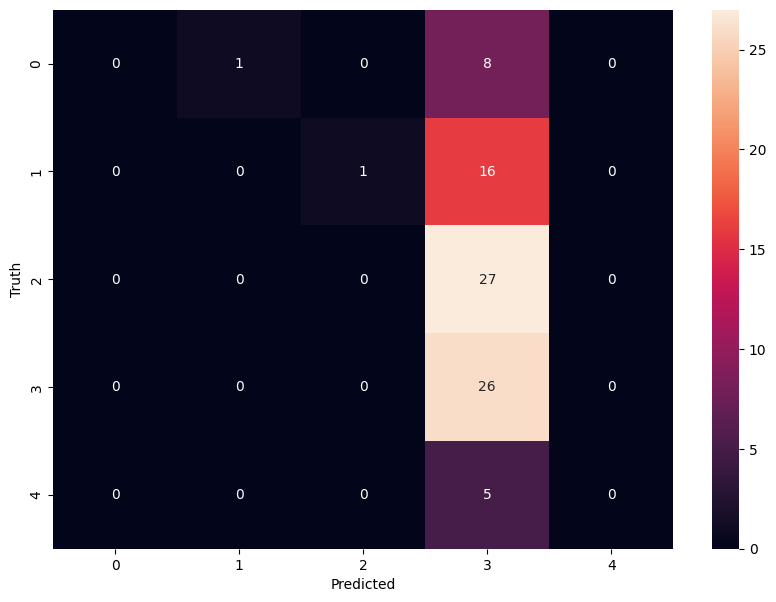

```python
#Confustion Matrix for test data
cm5=confusion_matrix(y_test_arg_l, y_pred_test_l)
plt.figure(figsize=(10,7))
sns.heatmap(cm5,annot=True,fmt='d')
plt.xlabel('Predicted')
plt.ylabel('Truth')
plt.show()
```

```python
# predicting the model on train data
#We cant directy use one hot encoded data hence following below steps
y_train_arg_l=np.argmax(Y_train,axis=1)
y_pred_train_l = np.argmax(lstm_model.predict(X_train),axis=1)
```

```python
#Accuracy of train data
acc_train_l=accuracy_score(y_train_arg_l, y_pred_train_l)
print('Accuracy of train data:',acc_train_l)
```

```
Accuracy of train data: 0.36826347305389223
```

```python
#Classification Report for train data
print(classification_report(y_train_arg_l, y_pred_train_l))
```

```
              precision    recall  f1-score   support

           0       0.00      0.00      0.00        36
           1       0.55      0.08      0.13        78
           2       0.50      0.03      0.05        79
           3       0.36      1.00      0.53       115
           4       0.00      0.00      0.00        25
           5       0.00      0.00      0.00         1

    accuracy                           0.37       334
   macro avg       0.23      0.18      0.12       334
weighted avg       0.37      0.37      0.23       334
```

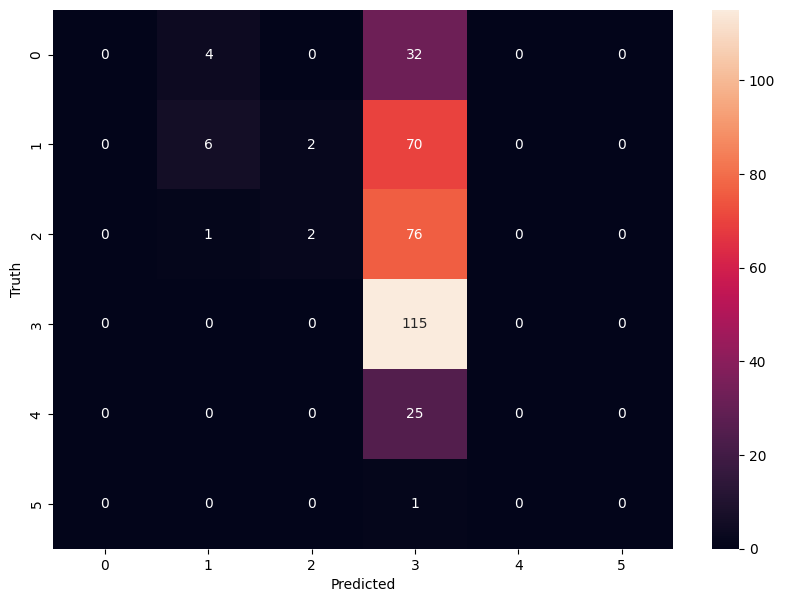

```python
#Confustion Matrix for train data
cm6=confusion_matrix(y_train_arg_l, y_pred_train_l)
plt.figure(figsize=(10,7))
sns.heatmap(cm6,annot=True,fmt='d')
plt.xlabel('Predicted')
plt.ylabel('Truth')
plt.show()
```

```python
#Loss and Accuracy curve
loss, accuracy  = lstm_model.evaluate(X_test,y_test_new, verbose=False)
```

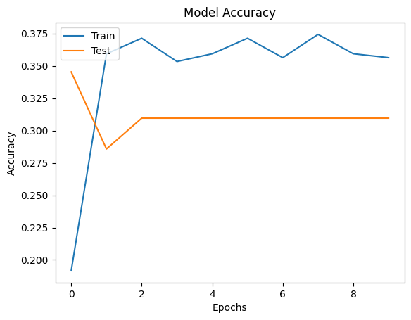

```python
#Summarize history for accuracy
#Plot Epoch vs Accuracy graph
plt.figure()
plt.plot(lstm_model1.history["accuracy"],label="Train");
plt.plot(lstm_model1.history["val_accuracy"],label="Test");
plt.title("Model Accuracy")
plt.ylabel("Accuracy")
plt.xlabel("Epochs")
plt.legend(['Train', 'Test'], loc='upper left')
plt.show();
```

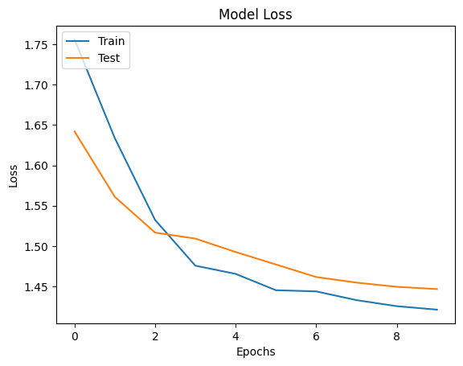

```python
#Summarize history for loss
#Plot Epochs vs Loss graph
plt.figure()
plt.plot(lstm_model1.history["loss"],label="Train");
plt.plot(lstm_model1.history["val_loss"],label="Test");
plt.title("Model Loss")
plt.ylabel("Loss")
plt.xlabel("Epochs")
plt.legend(['Train', 'Test'], loc='upper left')
plt.show();
```

```python
#Add the accuracy results to results_df dataframe
results_df=results_concat(results_df,acc_test_l,acc_train_l,'LSTM (simple model)')
```

**Summary on simple LSTM model results**:

Performance matrix of Training data:

Accuracy : 0.37

Precision : 0.37

Recall : 0.37

F1-score: 0.23

Performance matrix of Test data:

Accuracy : 0.31

Precision : 0.10

Recall : 0.31

F1-score: 0.15

Accuracy curve results:

Accuracy of training data was low initially but there was a sudden increase in Accuracy later. There is a slight fluctuations but training Accuracy curve looks ok after few epochs.

There is no sudden increase or decrease in Validation Accuracy. Slighly decreased in initial few epochs but gradually increased later and was constant for last few epochs. Validation accuracy range is in between 30-35%.

Loss curve results:

Loss of training data was high initially but there was a sudden decrease in Loss later. Loss curve looks ok for last few epochs.

Loss of validation data was high initially but there was a sudden decrease in Loss later. Loss curve looks good for last few epochs.

Validation and training data metrics are ok.

```python
#Define and compile complex LSTM model
#Input layer. Shape will be max length
input_layer = Input(shape=(maxlen,))
#Embedding layer
embedding=Embedding(vocab_size, embed_size, weights=[embedding_matrix], trainable=True)(input_layer)
#LSTM
lstm=Bidirectional(LSTM(128, return_sequences = True))(embedding)
#Max Pool
maxpool = GlobalMaxPool1D()(lstm)
#Drop out
dropout1 = Dropout(0.5, input_shape = (256,))(maxpool)
#Batch Normalization
batchnorm = BatchNormalization()(dropout1)
#Hidden layer
dense1 = Dense(128, activation = 'relu')(batchnorm)
#Drop out
dropout2 = Dropout(0.5, input_shape = (128,))(dense1)
#Hidden
dense2 = Dense(64, activation = 'relu')(dropout2)
#Drop out
dropout3 = Dropout(0.5, input_shape = (64,))(dense2)
#Hidden
dense3 = Dense(32, activation = 'relu')(dropout3)
#Dropout
dropout4 = Dropout(0.5, input_shape = (32,))(dense3)
#Hidden
dense4 = Dense(10, activation = 'relu')(dropout4)
#Dropout
dropout5 = Dropout(0.5, input_shape = (10,))(dense4)
#Output layer
output_layer = Dense(6, activation='softmax')(dropout5)
```

```python
lstm_model2 = Model(input_layer,output_layer)
#Compile model. Use SGD optimizer
sgd = SGD(learning_rate=0.001, momentum=0.9)
lstm_model2.compile(loss='categorical_crossentropy',optimizer="sgd",metrics=['accuracy'])
#display summary
lstm_model2.summary()
```

```
Model: "model_1"
_________________________________________________________________
 Layer (type)                Output Shape              Param #
=================================================================
 input_2 (InputLayer)        [(None, 100)]             0

 embedding_1 (Embedding)     (None, 100, 200)          558600

 bidirectional_1 (Bidirecti  (None, 100, 256)          336896
 onal)

 global_max_pooling1d (Glob  (None, 256)               0
 alMaxPooling1D)

 dropout_4 (Dropout)         (None, 256)               0

 batch_normalization_3 (Bat  (None, 256)               1024
 chNormalization)

 dense_11 (Dense)            (None, 128)               32896

 dropout_5 (Dropout)         (None, 128)               0

 dense_12 (Dense)            (None, 64)                8256

 dropout_6 (Dropout)         (None, 64)                0

 dense_13 (Dense)            (None, 32)                2080

 dropout_7 (Dropout)         (None, 32)                0

 dense_14 (Dense)            (None, 10)                330

 dropout_8 (Dropout)         (None, 10)                0

 dense_15 (Dense)            (None, 6)                 66

=================================================================
Total params: 940148 (3.59 MB)
Trainable params: 939636 (3.58 MB)
Non-trainable params: 512 (2.00 KB)
_________________________________________________________________
```

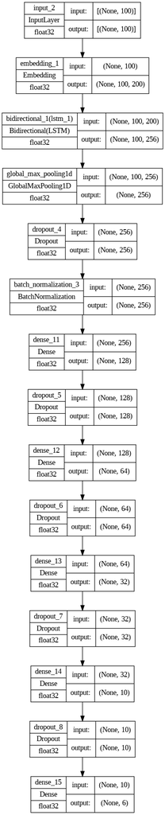

```python
#Save model to file
plot_model(lstm_model2, to_file='model_plot2.png', show_shapes=True, show_dtype=True, show_layer_names=True)
```

```python
#Set the parameters
callback = tf.keras.callbacks.EarlyStopping(monitor='loss', patience=7, min_delta=1E-3)
lr_reducton = ReduceLROnPlateau(monitor='val_loss', factor=0.0001, patience=5, min_delta=1E-4)
batch_size=256
epochs=10
```

```python
#Fit the model
lstm_model_2 = lstm_model2.fit(X_train,y_train_new,batch_size=batch_size, validation_data=(X_test, y_test_new), epochs=epochs, verbose=1,callbacks=lr_reducton)
```

```python
# list all data
print(lstm_model_2.history.keys())
```

```
dict_keys(['loss', 'accuracy', 'val_loss', 'val_accuracy', 'lr'])
```

```python
#Accuracy of training and testing data
print("Accuracy of the model on Training Data is - " ,lstm_model2.evaluate(X_train,y_train_new)[1]*100 , "%")
print("Accuracy of the model on Testing Data is - " ,lstm_model2.evaluate(X_test,y_test_new)[1]*100,"%")
```

```
Accuracy of the model on Training Data is -  34.4311386346817 %
Accuracy of the model on Testing Data is -  30.95238208770752 %
```

```python
# predicting the model on test data
#We cant directy use one hot encoded data hence following below steps
y_test_arg_l_2=np.argmax(Y_test,axis=1)
y_pred_test_l_2 = np.argmax(lstm_model2.predict(X_test),axis=1)
```

```python
#Accuracy of test data
acc_test_l_2=accuracy_score(y_test_arg_l_2, y_pred_test_l_2)
print('Accuracy of test data:',acc_test_l_2)
```

```
Accuracy of test data: 0.30952380952380953
```

```python
#Classification Report for test data
print(classification_report(y_test_arg_l_2, y_pred_test_l_2))
```

```
              precision    recall  f1-score   support

           0       0.00      0.00      0.00         9
           1       0.00      0.00      0.00        17
           2       0.00      0.00      0.00        27
           3       0.31      1.00      0.47        26
           4       0.00      0.00      0.00         5

    accuracy                           0.31        84
   macro avg       0.06      0.20      0.09        84
weighted avg       0.10      0.31      0.15        84
```

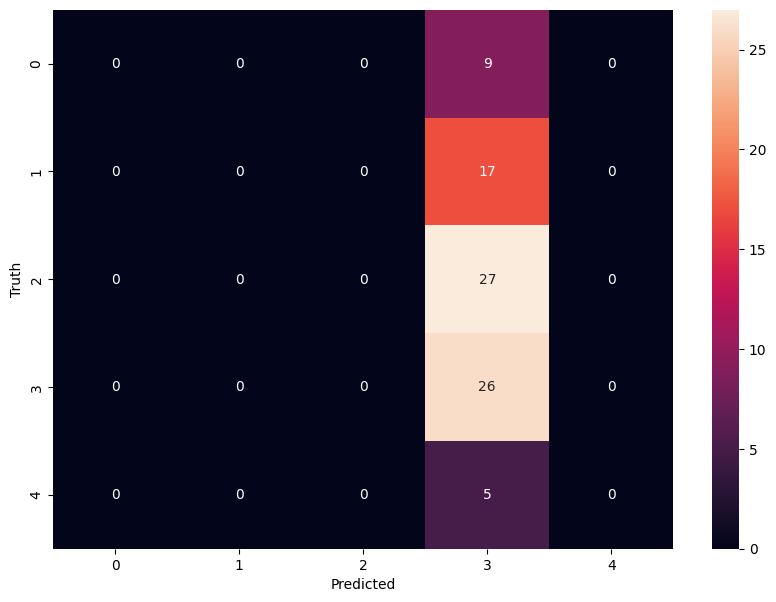

```python
#Confustion Matrix for test data
cm6=confusion_matrix(y_test_arg_l_2, y_pred_test_l_2)
plt.figure(figsize=(10,7))
sns.heatmap(cm6,annot=True,fmt='d')
plt.xlabel('Predicted')
plt.ylabel('Truth')
plt.show()
```

```python
# predicting the model on train data
#We cant directy use one hot encoded data hence following below steps
y_train_arg_l_2=np.argmax(Y_train,axis=1)
y_pred_train_l_2 = np.argmax(lstm_model2.predict(X_train),axis=1)
```

```python
#Accuracy of train data
acc_train_l_2=accuracy_score(y_train_arg_l_2, y_pred_train_l_2)
print('Accuracy of train data:',acc_train_l_2)
```

```
Accuracy of train data: 0.344311377245509
```

```python
#Classification Report for train data
print(classification_report(y_train_arg_l_2, y_pred_train_l_2))
```

```
              precision    recall  f1-score   support

           0       0.00      0.00      0.00        36
           1       0.00      0.00      0.00        78
           2       0.00      0.00      0.00        79
           3       0.34      1.00      0.51       115
           4       0.00      0.00      0.00        25
           5       0.00      0.00      0.00         1

    accuracy                           0.34       334
   macro avg       0.06      0.17      0.09       334
weighted avg       0.12      0.34      0.18       334
```

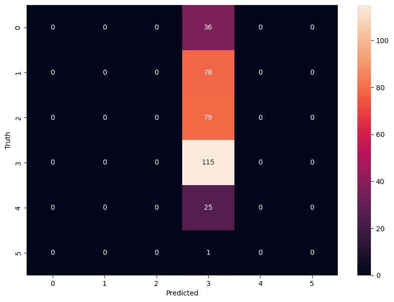

```python
#Confustion Matrix for train data
cm7=confusion_matrix(y_train_arg_l_2, y_pred_train_l_2)
plt.figure(figsize=(10,7))
sns.heatmap(cm7,annot=True,fmt='d')
plt.xlabel('Predicted')
plt.ylabel('Truth')
plt.show()
```

```python
#Loss and Accuracy curve
loss, accuracy  = lstm_model2.evaluate(X_test,y_test_new, verbose=False)
```

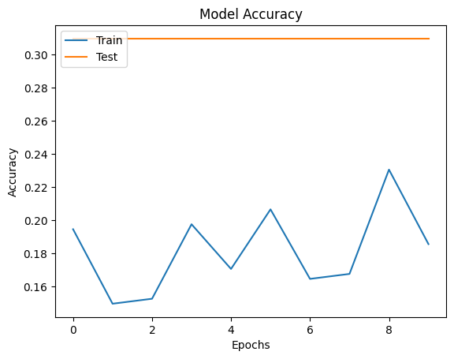

```python
#Summarize history for accuracy
#Plot Epoch vs Accuracy graph
plt.figure()
plt.plot(lstm_model_2.history["accuracy"],label="Train");
plt.plot(lstm_model_2.history["val_accuracy"],label="Test");
plt.title("Model Accuracy")
plt.ylabel("Accuracy")
plt.xlabel("Epochs")
plt.legend(['Train', 'Test'], loc='upper left')
plt.show();
```

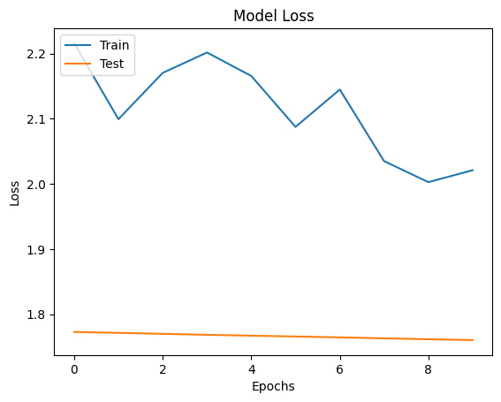

```python
#Summarize history for loss
#Plot Epochs vs Loss graph
plt.figure()
plt.plot(lstm_model_2.history["loss"],label="Train");
plt.plot(lstm_model_2.history["val_loss"],label="Test");
plt.title("Model Loss")
plt.ylabel("Loss")
plt.xlabel("Epochs")
plt.legend(['Train', 'Test'], loc='upper left')
plt.show();
```

```python
#Add the accuracy results to results_df dataframe
results_df=results_concat(results_df,acc_test_l_2,acc_train_l_2,'LSTM (complex model)')
```

**Summary on complex LSTM model results**:

Performance matrix of Training data:

Accuracy : 0.34

Precision : 0.12

Recall : 0.34

F1-score: 0.18

Performance matrix of Test data:

Accuracy : 0.31

Precision : 0.10

Recall : 0.31

F1-score: 0.15

Accuracy curve results:

There are slight fluctuations in Training data . Accuracy is increasing for few epochs and gradually decreasing for few.

Accuracy curve of validation data is constant .

Loss curve results:

There is slight fluctuations in Training data. Loss is decreasing for few epochs and gradually increasing for few.

Loss curve for validation data is low and constant.

```python
#Over sampling of data
# Converting the categorical values to one-hot encoding
y_train_new_1 = pd.get_dummies(y_train)
y_test_new_1 = pd.get_dummies(y_test)
```

```python
#Check the shape
print('Shape of y_train_new_1',y_train_new_1.shape)
print('Shape of y_test_new_1',y_test_new_1.shape)
```

```
Shape of y_train_new_1 (334, 6)
Shape of y_test_new_1 (84, 5)
```

```python
#Drop potential accident level 6 as it as only one data point
d = pd.DataFrame(Y_train)
d.drop(5,inplace=True,axis=1)
```

```python
#Data format suitable for SMOTE
Y_train_1 = np.asarray(d)
Y_test_1 = np.asarray(y_test_new_1)
```

```python
#Check the shape
print('Shape of y_train_1',Y_train_1.shape)
print('Shape of y_test_1',Y_test_1.shape)
```

```
Shape of y_train_1 (334, 5)
Shape of y_test_1 (84, 5)
```

```python
#Apply SMOTE for train data
X_OS, Y_OS = SMOTE(k_neighbors=1).fit_resample(X_train, Y_train_1)
print(X_OS.shape,'\n',Y_OS.shape)
```

```
(575, 100)
 (575, 5)
```

```python
#Apply SMOTE for test data
X_OS_T, Y_OS_T = SMOTE(k_neighbors=1).fit_resample(X_test, Y_test_1)
print(X_OS_T.shape,'\n',Y_OS_T.shape)
```

```
(135, 100)
 (135, 5)
```

```python
#Parameters
#Take 50 epochs
lr_reducton = ReduceLROnPlateau(monitor='val_accuracy', patience = 2, verbose=1,factor=0.5, min_lr=0.00001)
batch_size=256
epochs=50
```

```python
#Build a LSTM model
#Define and compile simple LSTM model
#Input layer. Shape will be max length
input_layer_1 = Input(shape=(maxlen,))
#Embedding layer
embedding=Embedding(vocab_size, embed_size, weights=[embedding_matrix], trainable=False)(input_layer_1)
#LSTM
lstm=Bidirectional(LSTM(128, return_sequences = True))(embedding)
#Max Pool
maxpool = GlobalMaxPool1D()(lstm)
#Drop out
dropout1 = Dropout(0.5, input_shape = (256,))(maxpool)
#Batch Normalization
batchnorm = BatchNormalization()(dropout1)
#Dense
dense =Dense(100,activation='relu')(batchnorm)
#Output layer. Use softmax activation
output_layer_1=Dense(5,activation='softmax')(dense)
```

```python
#Compile model
lstm_model3 = Model(input_layer_1,output_layer_1)
#Compile model. Use ADAM optimizer
lstm_model3.compile(loss='categorical_crossentropy',optimizer="adam",metrics=['accuracy'])
#display summary
lstm_model3.summary()
```

```
Model: "model_3"
_________________________________________________________________
 Layer (type)                Output Shape              Param #
=================================================================
 input_4 (InputLayer)        [(None, 100)]             0

 embedding_3 (Embedding)     (None, 100, 200)          558600

 bidirectional_3 (Bidirecti  (None, 100, 256)          336896
 onal)

 global_max_pooling1d_2 (Gl  (None, 256)               0
 obalMaxPooling1D)

 dropout_10 (Dropout)        (None, 256)               0

 batch_normalization_5 (Bat  (None, 256)               1024
 chNormalization)

 dense_18 (Dense)            (None, 100)               25700

 dense_19 (Dense)            (None, 5)                 505

=================================================================
Total params: 922725 (3.52 MB)
Trainable params: 363613 (1.39 MB)
Non-trainable params: 559112 (2.13 MB)
_________________________________________________________________
```

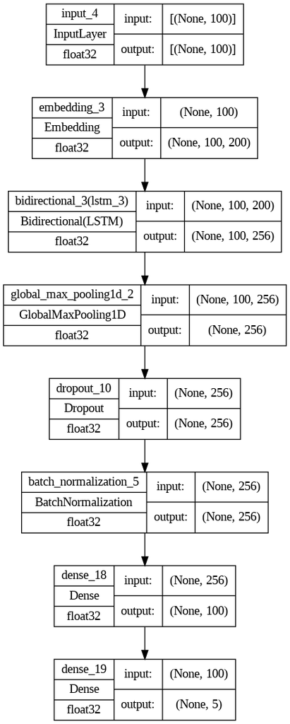

```python
#Save model to file
plot_model(lstm_model3, to_file='model_plot2.png', show_shapes=True, show_dtype=True, show_layer_names=True)
```

```python
#Fit model on SMOTE data
lstm_model_3 = lstm_model3.fit(X_OS,Y_OS,batch_size=batch_size, validation_data=(X_OS_T, Y_OS_T), epochs=epochs, verbose=1,callbacks=lr_reducton)
```

```
Epoch 3: ReduceLROnPlateau reducing learning rate to 0.0005000000237487257.
Epoch 5: ReduceLROnPlateau reducing learning rate to 0.0002500000118743628.
Epoch 7: ReduceLROnPlateau reducing learning rate to 0.0001250000059371814.
Epoch 9: ReduceLROnPlateau reducing learning rate to 6.25000029685907e-05.
Epoch 11: ReduceLROnPlateau reducing learning rate to 3.125000148429535e-05.
Epoch 13: ReduceLROnPlateau reducing learning rate to 1.5625000742147677e-05.
Epoch 15: ReduceLROnPlateau reducing learning rate to 1e-05.
```

```python
# list all data
print(lstm_model_3.history.keys())
```

```
dict_keys(['loss', 'accuracy', 'val_loss', 'val_accuracy', 'lr'])
```

```python
#Accuracy of training and testing data
print("Accuracy of the model on Training Data is - " ,lstm_model3.evaluate(X_OS,Y_OS)[1]*100 , "%")
print("Accuracy of the model on Testing Data is - " ,lstm_model3.evaluate(X_OS_T,Y_OS_T)[1]*100,"%")
```

```
Accuracy of the model on Training Data is -  58.95652174949646 %
Accuracy of the model on Testing Data is -  32.592591643333435 %
```

```python
# predicting the model on test data
#We cant directy use one hot encoded data hence following below steps
y_test_arg_l_s=np.argmax(Y_OS_T,axis=1)
y_pred_test_l_s = np.argmax(lstm_model3.predict(X_OS_T),axis=1)
```

```python
#Accuracy of test data
acc_test_l_s=accuracy_score(y_test_arg_l_s, y_pred_test_l_s)
print('Accuracy of test data:',acc_test_l_s)
```

```
Accuracy of test data: 0.32592592592592595
```

```python
#Classification Report for test data
print(classification_report(y_test_arg_l_s, y_pred_test_l_s))
```

```
              precision    recall  f1-score   support

           0       0.25      0.52      0.34        27
           1       0.50      0.37      0.43        27
           2       0.29      0.07      0.12        27
           3       0.47      0.33      0.39        27
           4       0.27      0.33      0.30        27

    accuracy                           0.33       135
   macro avg       0.36      0.33      0.31       135
weighted avg       0.36      0.33      0.31       135
```

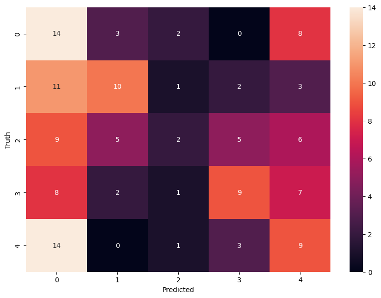

```python
#Confustion Matrix for test data
cm9=confusion_matrix(y_test_arg_l_s, y_pred_test_l_s)
plt.figure(figsize=(10,7))
sns.heatmap(cm9,annot=True,fmt='d')
plt.xlabel('Predicted')
plt.ylabel('Truth')
plt.show()
```

```python
# predicting the model on train data
#We cant directy use one hot encoded data hence following below steps
y_train_arg_l_s=np.argmax(Y_OS,axis=1)
y_pred_train_l_s = np.argmax(lstm_model3.predict(X_OS),axis=1)
```

```python
#Accuracy of train data
acc_train_l_s=accuracy_score(y_train_arg_l_s, y_pred_train_l_s)
print('Accuracy of train data:',acc_train_l_s)
```

```
Accuracy of train data: 0.5895652173913043
```

```python
#Classification Report for train data
print(classification_report(y_train_arg_l_s, y_pred_train_l_s))
```

```
              precision    recall  f1-score   support

           0       0.49      0.94      0.64       115
           1       0.72      0.41      0.52       115
           2       0.72      0.31      0.44       115
           3       0.79      0.51      0.62       115
           4       0.54      0.77      0.64       115

    accuracy                           0.59       575
   macro avg       0.65      0.59      0.57       575
weighted avg       0.65      0.59      0.57       575
```

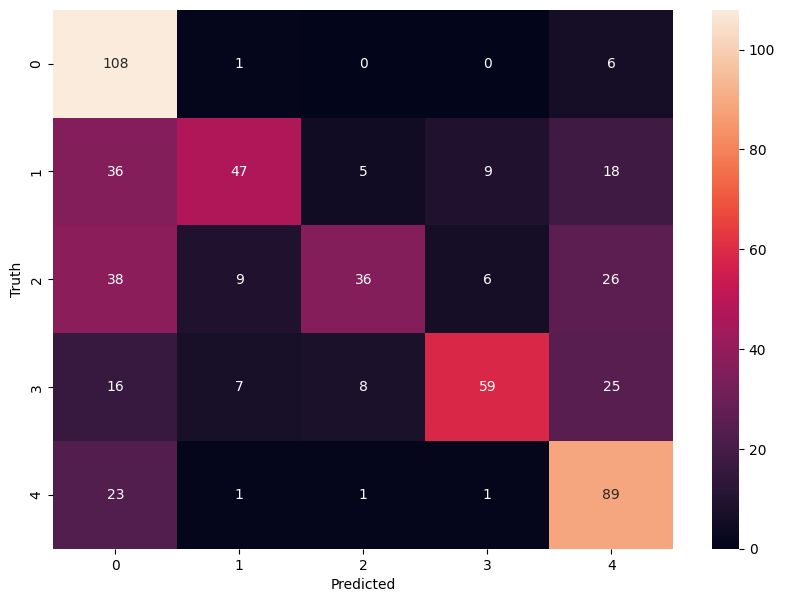

```python
#Confustion Matrix for train data
cm10=confusion_matrix(y_train_arg_l_s, y_pred_train_l_s)
plt.figure(figsize=(10,7))
sns.heatmap(cm10,annot=True,fmt='d')
plt.xlabel('Predicted')
plt.ylabel('Truth')
plt.show()
```

```python
#Loss and Accuracy curve
loss, accuracy  = lstm_model3.evaluate(X_OS_T,Y_OS_T, verbose=False)
```

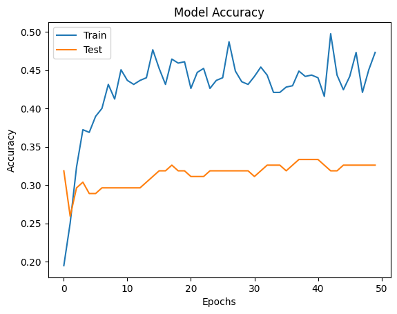

```python
#Summarize history for accuracy
#Plot Epoch vs Accuracy graph
plt.figure()
plt.plot(lstm_model_3.history["accuracy"],label="Train");
plt.plot(lstm_model_3.history["val_accuracy"],label="Test");
plt.title("Model Accuracy")
plt.ylabel("Accuracy")
plt.xlabel("Epochs")
plt.legend(['Train', 'Test'], loc='upper left')
plt.show();
```

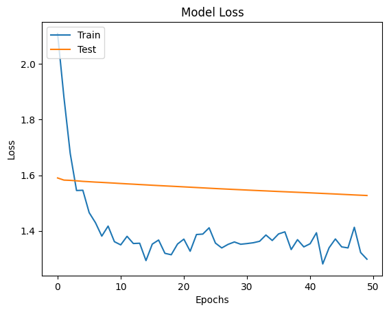

```python
#Summarize history for loss
#Plot Epochs vs Loss graph
plt.figure()
plt.plot(lstm_model_3.history["loss"],label="Train");
plt.plot(lstm_model_3.history["val_loss"],label="Test");
plt.title("Model Loss")
plt.ylabel("Loss")
plt.xlabel("Epochs")
plt.legend(['Train', 'Test'], loc='upper left')
plt.show();
```

```python
#Add the accuracy results to results_df dataframe
results_df=results_concat(results_df,acc_test_l_s,acc_train_l_s,'LSTM SMOTE')
```

**Summary on LSTM model using SMOTE data results**:

Performance matrix of Training data:

Accuracy : 0.59

Precision : 0.65

Recall : 0.59

F1-score: 0.57

Performance matrix of Test data:

Accuracy : 0.33

Precision : 0.36

Recall : 0.33

F1-score: 0.31

Accuracy curve results:

There are fluctuations in both validation and training data.Accuracy is increasing for few epochs and gradually decreasing for few.

Loss curve results:

There is slight fluctuation in training data.Loss is decreasing for few epochs and gradually increasing for few.

Loss curve for validation data is constant.

# **Conclusion on LSTM models**:

We have built three Neural Network. One was simple LSTM model , one was complex model and we use SMOTE balanced data for one model.

We have included Batch Normalization , Max pooling , Dropout and more hidden layers in complex model.

Techiniques like tokenization , sequencing and Glove embedding performed on the source data

Accuracy of LSTM model with balanced SMOTE data was better as compared to simple and complex LSTM model.

There were fluctuations in Accuracy and Loss curves for all three models.

Overall LSTM model with balanced SMOTE data gave better result.

```python
#Save comparision dataframe to csv
results_df.to_csv('/content/drive/MyDrive/CAPSTONE_PROJECT/results_df_final.csv', index=False)
```

# Step 3: Choose the best performing classifier and pickle it

```python
#Export the csv for accuracy comparsion
results_df = pd.read_csv('/content/drive/MyDrive/CAPSTONE_PROJECT/results_df_final.csv')
#Compare the results of all classifiers
print('Comparision of Results')
print(results_df)
```

```
Comparision of Results
                         Method  Accuracy of Test data  Accuracy of Train data
0           Logistic Regression               0.440476                1.000000
1                 Decision Tree               0.345238                0.398204
2                 Random Forest               0.440476                1.000000
3                      Adaboost               0.345238                0.431138
4       Bagging (Decision Tree)               0.476190                0.994012
5       Bagging (NB Classifier)               0.416667                0.910180
6   Bagging (LogReg Classifier)               0.416667                1.000000
7                Gradient Boost               0.345238                1.000000
8                           SVM               0.321429                1.000000
9                            NN               0.380952                0.907186
10                     NN Tuned               0.440000                0.880000
11          LSTM (simple model)               0.309524                0.368263
12         LSTM (complex model)               0.309524                0.344311
13                   LSTM SMOTE               0.325926                0.589565
```

```python
#We have copied all performance metrics in csv. We will export csv to display all the metrics values
results_df_all = pd.read_csv('/content/drive/MyDrive/CAPSTONE_PROJECT/results_df_all_metrics.csv')

print('All performance matrics comparision of each models\n')
results_df_all
```

```
All performance matrics comparision of each models
```

|  | Method | Accuracy of Test data | Precision of Test data | Recall of Test data | F1-score of Test data | Accuracy of Train data | Precision of Train data | Recall of Train data | F1-score of Train data |
| --- | --- | --- | --- | --- | --- | --- | --- | --- | --- |
| 0 | Logistic Regression | 0.440476 | 0.49 | 0.44 | 0.40 | 1.000000 | 1.00 | 1.00 | 1.00 |
| 1 | Decision Tree | 0.345238 | 0.21 | 0.35 | 0.20 | 0.398204 | 0.23 | 0.40 | 0.26 |
| 2 | Random Forest | 0.440476 | 0.47 | 0.44 | 0.39 | 1.000000 | 1.00 | 1.00 | 1.00 |
| 3 | Adaboost | 0.345238 | 0.35 | 0.35 | 0.23 | 0.431138 | 0.47 | 0.43 | 0.33 |
| 4 | Bagging (Decision Tree) | 0.476190 | 0.53 | 0.48 | 0.44 | 0.994012 | 0.99 | 0.99 | 0.99 |
| 5 | Bagging (NB Classifier) | 0.416667 | 0.41 | 0.42 | 0.36 | 0.910180 | 0.93 | 0.91 | 0.91 |
| 6 | Bagging (LogReg Classifier) | 0.416667 | 0.47 | 0.42 | 0.34 | 1.000000 | 1.00 | 1.00 | 1.00 |
| 7 | Gradient Boost | 0.345238 | 0.40 | 0.35 | 0.30 | 1.000000 | 1.00 | 1.00 | 1.00 |
| 8 | SVM | 0.321429 | 0.42 | 0.32 | 0.17 | 1.000000 | 1.00 | 1.00 | 1.00 |
| 9 | NN | 0.380952 | 0.41 | 0.38 | 0.35 | 0.907186 | 0.91 | 0.91 | 0.91 |
| 10 | NN Tuned | 0.440000 | 0.44 | 0.44 | 0.43 | 0.880000 | 0.88 | 0.88 | 0.88 |
| 11 | LSTM (simple model) | 0.309524 | 0.10 | 0.31 | 0.15 | 0.368263 | 0.37 | 0.37 | 0.23 |
| 12 | LSTM (complex model) | 0.309524 | 0.10 | 0.31 | 0.15 | 0.344311 | 0.12 | 0.34 | 0.18 |
| 13 | LSTM SMOTE | 0.325926 | 0.36 | 0.33 | 0.31 | 0.589565 | 0.65 | 0.59 | 0.57 |

```python
#Since training data is overfitted in most of models so we will consider only the models in which training data is not fully overfitted.
results_print=results_df_all.loc[results_df_all['Accuracy of Train data'] != 1]
results_print
```

|  | Method | Accuracy of Test data | Precision of Test data | Recall of Test data | F1-score of Test data | Accuracy of Train data | Precision of Train data | Recall of Train data | F1-score of Train data |
| --- | --- | --- | --- | --- | --- | --- | --- | --- | --- |
| 1 | Decision Tree | 0.345238 | 0.21 | 0.35 | 0.20 | 0.398204 | 0.23 | 0.40 | 0.26 |
| 3 | Adaboost | 0.345238 | 0.35 | 0.35 | 0.23 | 0.431138 | 0.47 | 0.43 | 0.33 |
| 4 | Bagging (Decision Tree) | 0.476190 | 0.53 | 0.48 | 0.44 | 0.994012 | 0.99 | 0.99 | 0.99 |
| 5 | Bagging (NB Classifier) | 0.416667 | 0.41 | 0.42 | 0.36 | 0.910180 | 0.93 | 0.91 | 0.91 |
| 9 | NN | 0.380952 | 0.41 | 0.38 | 0.35 | 0.907186 | 0.91 | 0.91 | 0.91 |
| 10 | NN Tuned | 0.440000 | 0.44 | 0.44 | 0.43 | 0.880000 | 0.88 | 0.88 | 0.88 |
| 11 | LSTM (simple model) | 0.309524 | 0.10 | 0.31 | 0.15 | 0.368263 | 0.37 | 0.37 | 0.23 |
| 12 | LSTM (complex model) | 0.309524 | 0.10 | 0.31 | 0.15 | 0.344311 | 0.12 | 0.34 | 0.18 |
| 13 | LSTM SMOTE | 0.325926 | 0.36 | 0.33 | 0.31 | 0.589565 | 0.65 | 0.59 | 0.57 |

# Comparision of all performance metrics

We have added 9 ML models , 2 NN models and 3 LSTM models for comparsion.

Training data is overfitted in Logistic Regression, Random Forest, Bagging (Decision Tree) , Bagging (NB Classifier),Bagging (LogReg Classifier), Gradient Boost , SVM.

So we can consider two ML models (Decision Tree , Adaboost) and 3 LSTM models for comparision.

In ML models , Accuracy is 35% for testing data in both ML models. Accuracy of training data is slighly higher in Adaboost. Precision and Recall for both training and testing data is better i Adaboost. Precision and F1-score is higher for test data in AdaBoost as compared to Decision tree.

Since the data is imbalanced , test data accuracy is same for both the models. we will compare the performance mertrics of each class. For class I both recall and f1 score is higher in Decision Tree but both models have same precision. For class II both the models have 0% performance metrics values. For class III , all the performannce metrics is 0% in Decision Tree but we have 33% precision , 4% recall and 7% F1-score in AdaBoost. For class IV , recall and precision values are higher in Decision tree but f1-score is higher in AdaBoost. For class V , all the performannce metrics is 0% in Decision Tree but we have 50% precision , 20% recall and 29% F1-score in AdaBoost. So in ML models we can consider Adaboost for comparsion.

In both the NN models training data is slightly overfitted . ie testing data have accuracy less than 50% but training data is greater than 88%.So we will not consider both the NN models for comparision.

In LSTM models , Accuracy and precision and recall values are better in LSTM SMOTE. Accuracy and Loss curve looks better in LSTM SMOTE as compared to other two LSTM models .

Since we have imbalanced data ,we will compare the performance mertrics of each class. We could see performance metrics for only CLASS III in LSTM Simple and Complex model. But since we have used the SMOTE to balance data , in LSTM SMOTE we could see the performance metrics fr all the classes in LSTM SMOTE. Accuracy is 0.33 , Precision is 0.36 , Recall is 0.33 and F1-score is 0.31 in LSTM SMOTE.

So in LSTM model we can consider LSTM SMOTE for comparision.

Now to decide the final best model we will compare AdaBoost and LSTM SMOTE.

Training data: All the performance metrics like Accuracy , Precision Recall and F1-score is higher in LSTM SMOTE as compared to AdaBoost.

Test data: Accuracy ane recall is slightly high in AdaBoost .Precision and F1-score is high in LSTM SMOTE.

Since the data is imbalanced , we will compare the performance mertrics of each class. In LSTM SMOTE we have removed one of the class due to the imbalance and outlier. We dont have any values for performance metrics in one of the class in AdaBoost. Precision is sligher higher in AdaBoost for all the four classes . Both Recall and F1-score is higher in LSTM SMOTE for three classes.

Accuracy and Loss curve looks good for LSTM SMOTE.

Training data accuracy is good in LSTM SMOTE. There are very small difference for Accuracy (2%) , Recall(2%) and precision (1%). But F1-score was 8% higher in LSTM SMOTE as compared to AdaBoost. Class wise performance metrics was better is LSTM SMOTE as compared to AdaBoost.

AdaBoost uses a progressively learning boosting technique. Hence high-quality data is needed to get better result in AdaBoost . It is also very sensitve to outliers.

Considering all this we can choose LSTM SMOTE as a best performing classifier.

```python
#Pickle the best performing classifier
#Pickle the selected model for future use.
#lstm_model3 is the LSTM SMOTE model object.
lstm_model3.fit(X_OS,Y_OS)
#To save the LSTM model using Pickle all we need to do is pass the model object into the dump() function of Pickle
pickle.dump(lstm_model3, open('lstm_model3.pkl', 'wb'))
```

```python
#Load the model from Pickle
pickled_model = pickle.load(open('lstm_model3.pkl', 'rb'))
pickled_model.predict(X_OS_T)
```

[output not shown]

[output cut: 81 more lines]

```
       [0.26628864, 0.15623201, 0.17127226, 0.18946871, 0.21673836],
       [0.2756534 , 0.13677686, 0.15735398, 0.1983362 , 0.23187955],
       [0.28248107, 0.16122636, 0.14893474, 0.19108045, 0.21627747],
       [0.26649857, 0.15685783, 0.17133825, 0.1891669 , 0.2161385 ],
       [0.29080528, 0.1478577 , 0.13660018, 0.23042573, 0.19431108],
       [0.26703495, 0.17942588, 0.15892997, 0.22026937, 0.17433979],
       [0.271354  , 0.17553774, 0.14246356, 0.18597586, 0.22466883],
       [0.24576424, 0.16191709, 0.15851267, 0.19979595, 0.23401004],
       [0.26408803, 0.14973989, 0.16148673, 0.2093465 , 0.21533878],
       [0.25298005, 0.1722832 , 0.16986744, 0.19559626, 0.20927301],
       [0.27563587, 0.15630324, 0.16018184, 0.19133717, 0.21654184],
       [0.262516  , 0.1883065 , 0.16127212, 0.16078812, 0.2271173 ],
       [0.285554  , 0.1454546 , 0.14996368, 0.19659558, 0.22243214],
       [0.25415948, 0.16936457, 0.16151108, 0.20172954, 0.21323538]],
      dtype=float32)
```

We have used potential accident level and description columns from pre-processed file and built the above models.We have selected one best model with better accuracy and pickled it. But accuracy was not very high for all these models.

**So we will try to get better accuracy using different column ie accident level**. We will now use accident level column along with description from existing pre-processed file, apply few additional pre-processing on these two columns and build one LSTM model.

```python
#Read the pre-processed data to new dataframe
data_m2 = pd.read_csv('/content/drive/MyDrive/CAPSTONE_PROJECT/industrial_safety_and_health_database.csv')
```

```python
#Display top 5 data
data_m2.head()
```

|  | Accident Level | Potential Accident Level | Description | Year | Month | Day | Weekday | WeekofYear | Season | Country_02 | ... | CR_Projection | CR_Projection of fragments | CR_Projection/Burning | CR_Projection/Choco | CR_Projection/Manual Tools | CR_Suspended Loads | CR_Traffic | CR_Vehicles and Mobile Equipment | CR_Venomous Animals | CR_remains of choco |
| --- | --- | --- | --- | --- | --- | --- | --- | --- | --- | --- | --- | --- | --- | --- | --- | --- | --- | --- | --- | --- | --- |
| 0 | I | IV | removing drill rod jumbo 08 maintenance superv... | 2016 | 1 | 1 | 4 | 53 | 0 | 0.0 | ... | 0.0 | 0.0 | 0.0 | 0.0 | 0.0 | 0.0 | 0.0 | 0.0 | 0.0 | 0.0 |
| 1 | I | IV | activation sodium sulphide pump piping uncoupl... | 2016 | 1 | 2 | 5 | 53 | 0 | 1.0 | ... | 0.0 | 0.0 | 0.0 | 0.0 | 0.0 | 0.0 | 0.0 | 0.0 | 0.0 | 0.0 |
| 2 | I | III | substation milpo located level 170 collaborato... | 2016 | 1 | 6 | 2 | 1 | 0 | 0.0 | ... | 0.0 | 0.0 | 0.0 | 0.0 | 0.0 | 0.0 | 0.0 | 0.0 | 0.0 | 0.0 |
| 3 | I | I | 945 approximately nv 1880 cx695 ob7 personnel ... | 2016 | 1 | 8 | 4 | 1 | 0 | 0.0 | ... | 0.0 | 0.0 | 0.0 | 0.0 | 0.0 | 0.0 | 0.0 | 0.0 | 0.0 | 0.0 |
| 4 | IV | IV | approximately 1145 circumstance mechanic antho... | 2016 | 1 | 10 | 6 | 1 | 0 | 0.0 | ... | 0.0 | 0.0 | 0.0 | 0.0 | 0.0 | 0.0 | 0.0 | 0.0 | 0.0 | 0.0 |

5 rows × 59 columns

```python
# Select input and output features
X_text = data_m2['Description']
y_text = data_m2['Accident Level']
```

```python
#Lemmatizer
lemmatizer = WordNetLemmatizer()
```

```python
#Function to remove stop words
stop_words = set(stopwords.words('english'))
def remove_stopwords(text):
    return " ".join([word for word in text.split() if word not in stop_words])
```

```python
#Function to remove punctuation
def remove_punctuation(text):
    return text.translate(str.maketrans('', '', string.punctuation))
```

```python
print('--'*30); print('Converting description to lower case')
data_m2['Cleaned_Description'] = data_m2['Description'].apply(lambda x : x.lower())

print('Removing punctuations')
data_m2['Cleaned_Description'] = data_m2['Cleaned_Description'].apply(lambda x: remove_punctuation(x))

print('Applying Lemmatizer')
data_m2['Cleaned_Description'] = data_m2['Cleaned_Description'].apply(lambda x: lemmatizer.lemmatize(x))

print('Removing multiple spaces between words')
data_m2['Cleaned_Description'] = data_m2['Cleaned_Description'].apply(lambda x: re.sub(' +', ' ', x))

print('Removing stop words')
data_m2['Cleaned_Description'] = data_m2['Cleaned_Description'].apply(lambda x: remove_stopwords(x))

print('--'*30)
```

```
------------------------------------------------------------
Converting description to lower case
Removing punctuations
Applying Lemmatizer
Removing multiple spaces between words
Removing stop words
------------------------------------------------------------
```

```python
X_text = data_m2['Cleaned_Description']
y_text = data_m2['Accident Level']
```

```python
X_text.head()
```

```
0    removing drill rod jumbo 08 maintenance superv...
1    activation sodium sulphide pump piping uncoupl...
2    substation milpo located level 170 collaborato...
3    945 approximately nv 1880 cx695 ob7 personnel ...
4    approximately 1145 circumstance mechanic antho...
Name: Cleaned_Description, dtype: object
```

```python
# Encode labels in column 'Accident Level'.
y_text = LabelEncoder().fit_transform(y_text)
```

```python
# Divide the data into testing and training sets:
X_text_train, X_text_test, y_text_train, y_text_test = train_test_split(X_text, y_text, test_size = 0.20, random_state = 1, stratify = y_text)

print('X_text_train shape : ({0})'.format(X_text_train.shape[0]))
print('y_text_train shape : ({0},)'.format(y_text_train.shape[0]))
print('X_text_test shape : ({0})'.format(X_text_test.shape[0]))
print('y_text_test shape : ({0},)'.format(y_text_test.shape[0]))
```

```
X_text_train shape : (334)
y_text_train shape : (334,)
X_text_test shape : (84)
y_text_test shape : (84,)
```

```python
#convert the vector
y_text_train = to_categorical(y_text_train)
y_text_test = to_categorical(y_text_test)
```

```python
print(y_text_train)
```

```
[[0. 1. 0. 0. 0.]
 [0. 1. 0. 0. 0.]
 [1. 0. 0. 0. 0.]
 ...
 [1. 0. 0. 0. 0.]
 [1. 0. 0. 0. 0.]
 [0. 1. 0. 0. 0.]]
```

```python
#Tokenizer and text to sequences to transforms each text in texts to a sequence of integers
tokenizer = Tokenizer(num_words=5000)
tokenizer.fit_on_texts(X_text_train)
X_text_train = tokenizer.texts_to_sequences(X_text_train)
X_text_test = tokenizer.texts_to_sequences(X_text_test)
```

```python
print(X_text_train[0])
```

```
[445, 145, 935, 1428, 446, 160, 132, 196, 1429, 447, 40, 36, 133, 146, 3, 2]
```

```python
#Get Vocabulary size and max length. Use pad sequences to ensure that input sequences have the same length by padding them  max length
vocab_size = len(tokenizer.word_index) + 1
print("vocab_size:", vocab_size)

maxlen = 100

X_text_train = pad_sequences(X_text_train, padding='post', maxlen=maxlen)
X_text_test = pad_sequences(X_text_test, padding='post', maxlen=maxlen)
```

```
vocab_size: 2858
```

```python
# We need to load the built-in GloVe word embeddings
embedding_size = 200
embeddings_dictionary = dict()

glove_file = '/content/glove.6B.200d.txt'

for line in open(glove_file):
    records = line.split()
    word = records[0]
    vector_dimensions = np.asarray(records[1:], dtype='float32')
    embeddings_dictionary[word] = vector_dimensions

embedding_matrix = np.zeros((vocab_size, embedding_size))

for word, index in tokenizer.word_index.items():
    embedding_vector = embeddings_dictionary.get(word)
    if embedding_vector is not None:
        embedding_matrix[index] = embedding_vector

len(embeddings_dictionary.values())
```

```
400000
```

```python
os.environ['PYTHONHASHSEED']=str(7)

# Reproduce the results
def reset_random_seeds():
   os.environ['PYTHONHASHSEED']=str(7)
   tf.random.set_seed(7)
```

```python
reset_random_seeds()

# Build a LSTM Neural Network
deep_inputs = Input(shape=(maxlen,))
#Embedding layer
embedding_layer = Embedding(vocab_size, embedding_size, weights=[embedding_matrix], trainable=False)(deep_inputs)
#LSTM
LSTM_Layer_1 = Bidirectional(LSTM(128, return_sequences = True))(embedding_layer)
#Max Pool
max_pool_layer_1 = GlobalMaxPool1D()(LSTM_Layer_1)
#Dropout
drop_out_layer_1 = Dropout(0.5, input_shape = (256,))(max_pool_layer_1)
#Hidden
dense_layer_1 = Dense(128, activation = 'relu')(drop_out_layer_1)
#Dropout
drop_out_layer_2 = Dropout(0.5, input_shape = (128,))(dense_layer_1)
#Hidden
dense_layer_2 = Dense(64, activation = 'relu')(drop_out_layer_2)
#Dropout
drop_out_layer_3 = Dropout(0.5, input_shape = (64,))(dense_layer_2)
#Hidden
dense_layer_3 = Dense(32, activation = 'relu')(drop_out_layer_3)
#Dropout
drop_out_layer_4 = Dropout(0.5, input_shape = (32,))(dense_layer_3)
#Hidden
dense_layer_4 = Dense(10, activation = 'relu')(drop_out_layer_4)
#Dropout
drop_out_layer_5 = Dropout(0.5, input_shape = (10,))(dense_layer_4)
#Output layer
dense_layer_5 = Dense(5, activation='softmax')(drop_out_layer_5)

model = Model(inputs=deep_inputs, outputs=dense_layer_5)

opt = SGD(learning_rate=0.001, momentum=0.9)
model.compile(loss='categorical_crossentropy', optimizer=opt, metrics=['acc'])
```

```python
#Summary
print(model.summary())
```

```
Model: "model_1"
_________________________________________________________________
 Layer (type)                Output Shape              Param #
=================================================================
 input_2 (InputLayer)        [(None, 100)]             0

 embedding_1 (Embedding)     (None, 100, 200)          571600

 bidirectional_1 (Bidirecti  (None, 100, 256)          336896
 onal)

 global_max_pooling1d_1 (Gl  (None, 256)               0
 obalMaxPooling1D)

 dropout_5 (Dropout)         (None, 256)               0

 dense_5 (Dense)             (None, 128)               32896

 dropout_6 (Dropout)         (None, 128)               0

 dense_6 (Dense)             (None, 64)                8256

 dropout_7 (Dropout)         (None, 64)                0

 dense_7 (Dense)             (None, 32)                2080

 dropout_8 (Dropout)         (None, 32)                0

 dense_8 (Dense)             (None, 10)                330

 dropout_9 (Dropout)         (None, 10)                0

 dense_9 (Dense)             (None, 5)                 55

=================================================================
Total params: 952113 (3.63 MB)
Trainable params: 380513 (1.45 MB)
Non-trainable params: 571600 (2.18 MB)
_________________________________________________________________
None
```

```python
#Class metrics for performance metrics
class Metrics(tf.keras.callbacks.Callback):

    def __init__(self, validation_data=()):
        super().__init__()
        self.validation_data = validation_data

    def on_train_begin(self, logs={}):
        self.val_f1s = []
        self.val_recalls = []
        self.val_precisions = []

    def on_epoch_end(self, epoch, logs={}):
        xVal, yVal, target_type = self.validation_data
        if target_type == 'multi_class':
          val_predict_classes = model.predict_classes(xVal, verbose=0) # Multiclass
        else:
          val_predict_classes = (np.asarray(self.model.predict(xVal))).round() # Multilabel


        val_targ = yVal

        _val_f1 = f1_score(val_targ, val_predict_classes, average='micro')
        _val_recall = recall_score(val_targ, val_predict_classes, average='micro')
        _val_precision = precision_score(val_targ, val_predict_classes, average='micro')
        self.val_f1s.append(_val_f1)
        self.val_recalls.append(_val_recall)
        self.val_precisions.append(_val_precision)
        return
```

```python
#Callbacks
callback = tf.keras.callbacks.EarlyStopping(monitor='loss', patience=7, min_delta=1E-3)
rlrp = ReduceLROnPlateau(monitor='val_loss', factor=0.0001, patience=5, min_delta=1E-4)

target_type = 'multi_label'

metrics = Metrics(validation_data=(X_text_train, y_text_train, target_type))
#fit the model
training_history = model.fit(X_text_train, y_text_train, epochs=100, batch_size=8, verbose=1, validation_data=(X_text_test, y_text_test), callbacks=[rlrp, metrics])
```

```python
# Evaluate the keras model
_, train_accuracy = model.evaluate(X_text_train, y_text_train, batch_size=8, verbose=0)
_, test_accuracy = model.evaluate(X_text_test, y_text_test, batch_size=8, verbose=0)

print('Train accuracy: %.2f' % (train_accuracy*100))
print('Test accuracy: %.2f' % (test_accuracy*100))
```

```
Train accuracy: 73.95
Test accuracy: 73.81
```

```python
#Function to get performance metrics
def get_classification_metrics(model, X_test, y_test, target_type):

  # predict probabilities for test set
  yhat_probs = model.predict(X_test, verbose=0) # Multiclass

  # predict crisp classes for test set
  if target_type == 'multi_class':
    yhat_classes = model.predict_classes(X_test, verbose=0) # Multiclass
  else:
    yhat_classes = (np.asarray(model.predict(X_test))).round() # Multilabel

  # reduce to 1d array
  yhat_probs = yhat_probs[:, 0]

  # accuracy: (tp + tn) / (p + n)
  accuracy = accuracy_score(y_test, yhat_classes)

  # precision tp / (tp + fp)
  precision = precision_score(y_test, yhat_classes, average='micro')

  # recall: tp / (tp + fn)
  recall = recall_score(y_test, yhat_classes, average='micro')

  # f1: 2 tp / (2 tp + fp + fn)
  f1 = f1_score(y_test, yhat_classes, average='micro')

  return accuracy, precision, recall, f1
```

```python
accuracy, precision, recall, f1 = get_classification_metrics(model, X_text_test, y_text_test, target_type)
print('Accuracy: %f' % accuracy)
print('Precision: %f' % precision)
print('Recall: %f' % recall)
print('F1 score: %f' % f1)
```

```
Accuracy: 0.738095
Precision: 0.738095
Recall: 0.738095
F1 score: 0.738095
```

```python
#Loss and Accuracy curve
loss, accuracy  = model.evaluate(X_text_test, y_text_test, verbose=False)
```

```python
accuracy
```

```
0.738095223903656
```

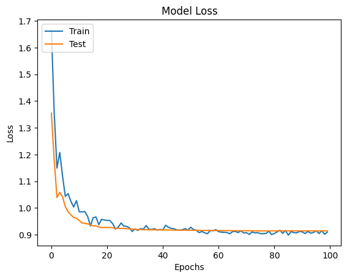

```python
#Summarize history for loss
#Plot Epochs vs Loss graph
plt.figure()
plt.plot(training_history.history["loss"],label="Train");
plt.plot(training_history.history["val_loss"],label="Test");
plt.title("Model Loss")
plt.ylabel("Loss")
plt.xlabel("Epochs")
plt.legend(['Train', 'Test'], loc='upper left')
plt.show();
```

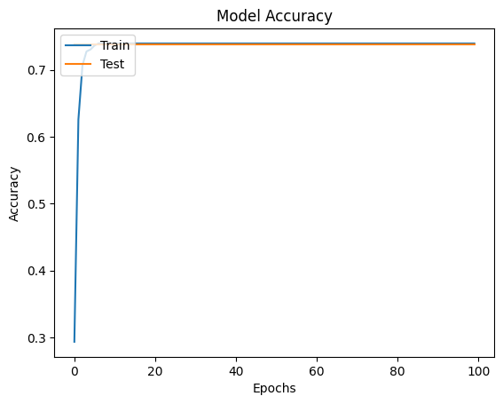

```python
#Summarize history for accuracy
#Plot Epoch vs Accuracy graph
plt.figure()
plt.plot(training_history.history["acc"],label="Train");
plt.plot(training_history.history["val_acc"],label="Test");
plt.title("Model Accuracy")
plt.ylabel("Accuracy")
plt.xlabel("Epochs")
plt.legend(['Train', 'Test'], loc='upper left')
plt.show();
```

**When we used the accident level column and built the LSTM model we had 74% accuracy , Recall , Precision and F1-score for test data**.

There are slight fluctuations in Training loss curve but both Accuracy and Loss curve looks good.

Hence we will pickle this model as well for future use.

```python
#Pickle the best performing classifier
#Pickle the selected model for future use.
#model is the LSTM model object.
model.fit(X_text_train, y_text_train)
#To save the ML model using Pickle all we need to do is pass the model object into the dump() function of Pickle
pickle.dump(model, open('model.pkl', 'wb'))
```

```python
#Load the model from Pickle
pickled_model = pickle.load(open('model.pkl', 'rb'))
pickled_model.predict(X_text_train)
```

```
array([[0.73092526, 0.0935503 , 0.07469856, 0.0725747 , 0.02825109],
       [0.73043215, 0.09324986, 0.0752776 , 0.07289716, 0.02814326],
       [0.73034215, 0.09227847, 0.0757106 , 0.07347713, 0.02819159],
       ...,
       [0.73075724, 0.09202842, 0.07568139, 0.07336897, 0.02816399],
       [0.73039085, 0.09175095, 0.07590061, 0.07378761, 0.02816997],
       [0.731371  , 0.09325072, 0.07431433, 0.07259566, 0.02846826]],
      dtype=float32)
```

# **Summary of the Project**

**DOMAIN:** Industrial safety. NLP based Chatbot

**DESCRIPTION**: This database is basically records of accidents from 12 different plants in 03 different countries which every line in the data is an occurrence of an accident.

**OBJECTIVE**: Design a ML/DL based chatbot utility which can help the professionals to highlight the safety risk as per the incident description

**TASKS:** Tasks are performed in two milestones.

**MILESTONE1 :**

We have first imported the data . Checked the info , shape, number of columns in the data.

In the second step we have performed Data cleansing. Dropped duplicates. Check for unique values , NULL values .Drop unwanted columns. Visualise the missing values. Rrenamed few columns and check the outliers.

In the third step we have performed Date preprocessing. Extract various columns like year, day, month and season. Convert description to lowercase .Remove special characters and stop words .Apply lematizer and tokenizer on data.

Additionally performed dummy variable encoding and label encoding . Checked correlation . Performed Univariate and Bivariate analysis of various columns and Visualized data.

Fourth step is the Data Preparation. We have first removed columns which is not required for modelling .Checked for NULL values , duplicate records and standard deviation. Once we are satisfied with data, we have copied the dataframe to csv and xlsx for future use.

In the fifth step, we have first imported the preprocessed csv file.Description and Potential Accident level columns were used for all models. Split test and train data. We have then used bag of words feature extraction on the split data. Defined function to fit the model ,calculate performance metrics and concatenate the accuracy results of each model. Built model codes which in turn calls functions to fit data , obtain accuracy and concatenate model results. We have re-used the functions and built nine Machine Learning models . Defined a Standard Scaler to normalize inputs. Set up the k-fold cross-validation. Used Pipeline on each model and used Grid search Hyper parameter tuning. Accuracy results , Classification Report results (Accuracy , Precision , Recall , F1-score) and Confusion Matrix results are displayed for each model. We have noticed training data overfitting in most of the models. On comparing the model results we have selected best model as AdaBoost.

Additionally we have exported the comparision results to csv for future use.

**MILESTONE2** : Input is the Preprocessed output from Milestone-1.

We have used existing train and test data (used by ML models).

Performed few additional steps like reset and sort index , converting the categorical values to one-hot encoding , add missing column to test data, transform Labels into format acceptable by Neural Network.

Designed, trained and test Neural networks classifiers. Here we built two Neural network models (one simple Neural network and one tuned neural network) and then compared the results. Applied Dense Neural Network with different activation functions and parameter tuning. We have included Batch Normalization , Dropout and more hidden layers in tuned model. Accuracy results , Classification Report results (Accuracy , Precision , Recall , F1-score), Confusion Matrix results , Accuracy and Loss curves are displayed for both Neural Network models. It yields good accuracy in training data butoverfitting due to the complex model. Overfitting was slighly reduced in Tuned model. Accuracy of tuned model was better. Accuracy and Loss curve of both Training data and testing data was better in tuned model. We have appended the Neural Network models accuracy results with Machine Learning model results.

Prior to building LSTM models , we have performed few techiniques like tokenization , sequencing , define few parameters like max length , embedding size , max features and create a weight matrix using GloVe embeddings on source data.

Next step is to choose the best performing classifier and pickle it. On comparing nine Machine learning , two Neural Network and three LSTM models we have selected LSTM SMOTE as a best performing classifier and picked it.

We have used potential accident level and description columns from pre-processed file and built the above models. We have selected one best model with better accuracy and pickled it. But accuracy was not very high for all these models.

So we tried to get better accuracy using different column ie accident level. We have used accident level column along with description from existing pre-processed file, applied few additional pre-processing on these two columns and built one LSTM model. When we used the accident level column and built the LSTM model we had very good accuracy , Recall , Precision and F1-score for test data. It was 74%. There are slight fluctuations in Training loss curve but both Accuracy and Loss curve looks good. Hence we have pickled this model as well for future use.

# **CONCLUSION**:

1. There were seven duplicates in the dataset, dropped them.
2. There were no missing values in the dataset.
3. Deleted unwanted features and created new features using Label encoding and Dummy variable/one hot encoding.
4. Applied NLP data pre-processing like converting to lower case. Removing special characters, Removing stop words, Lemmatization on Accident Decsription.
5. We have used Grid search for hyperparameter tuning in Machine Learning models.
6. Class imbalance issue is handled using SMOTE.
7. We were able to predict the potential accident level with a test accuracy of 48%.
8. We were able to predict the accident level with a test accuracy of 74%.
9. For potential accident level , by comparing the performance metrics of all nine Machine learning models , two Neural Network models and three LSTM models we have selected LSTM SMOTE as a best model and pickled it for future use.
10. For accident level , we have built only one LSTM model . Since this model had a good accuracy , precision , recall and f1-score we have selected this model and pickled it for future use.

# **LIMITATIONS** :

1. We have less number of observations to analyse the cause of accidents correctly.
2. We have less number of features available in dataset.
3. The quality and relevance of the data can greatly impact the performance of the model.

# **IMPROVEMENTS** :

1. Opting for Potential Accident Level as our target variables might have caused lower accuracy , precision and re-call when model was applied on raw data as well as over sampled data. We can use Accident Level as our target variable and compare the model results.
2. Adding more data. Large datasets can provide more accurate and robust models.
3. Machine learning (ML) models generally consume a lot of training data due to the large number of tunable parameters and lack of priors.So we can either use simpler models or build in priors to reduce data requirements during learning and hence making the models learn faster and more efficiently with possibility of better generalization performance.
4. We have to explore and implement more preprocessing techniques.
5. We have to explore and implement more feature engineering and feature selection techniques.
6. Increase model capacity.To increase the capacity, we add layers and nodes to a deep network gradually.
7. Model & dataset design changes.Analze bad predictions in validation data, Shuffle the dataset. Balance the dataset so that each class has similar amount of samples.Monitor the activations.Monitor the percentage of dead nodes. If the deep network has a huge amount of dead nodes, we should trace the problem further.
8. We have to dig deeper into performance metrics. Performance metrics can be improved by using PCA or by increasing dimensions or by using learning rate tuning, dropouts,early stopping and hyper parameter tuning more efficiently.
9. Overfitting can be reduced by stopping the training when the validation errors increase persistently.